# Linear Regression - Predicting Individual Medical Costs Billed by Health Insurance

4/18/2020

## Exploratory Data Analysis

In the insurance CSV file there were 7 variables and 1338 observations. Of these variables three were categorical and four were continuous. The categorical variables were sex with its highest category being male at 50.5%, smoker with its highest category being no at 79.5%, and region with its highest category being southeast at 27.2%. The continuous variables were age with a mean of 39.2 and a standard deviation of 14.0, bmi with a mean of 30.7 and a standard deviation of 6.1, children with a mean of 1.1 and a standard deviation of 1.2, and charges with a mean of 13270.4 and a standard deviation of 12110.0.

## Data Visualization

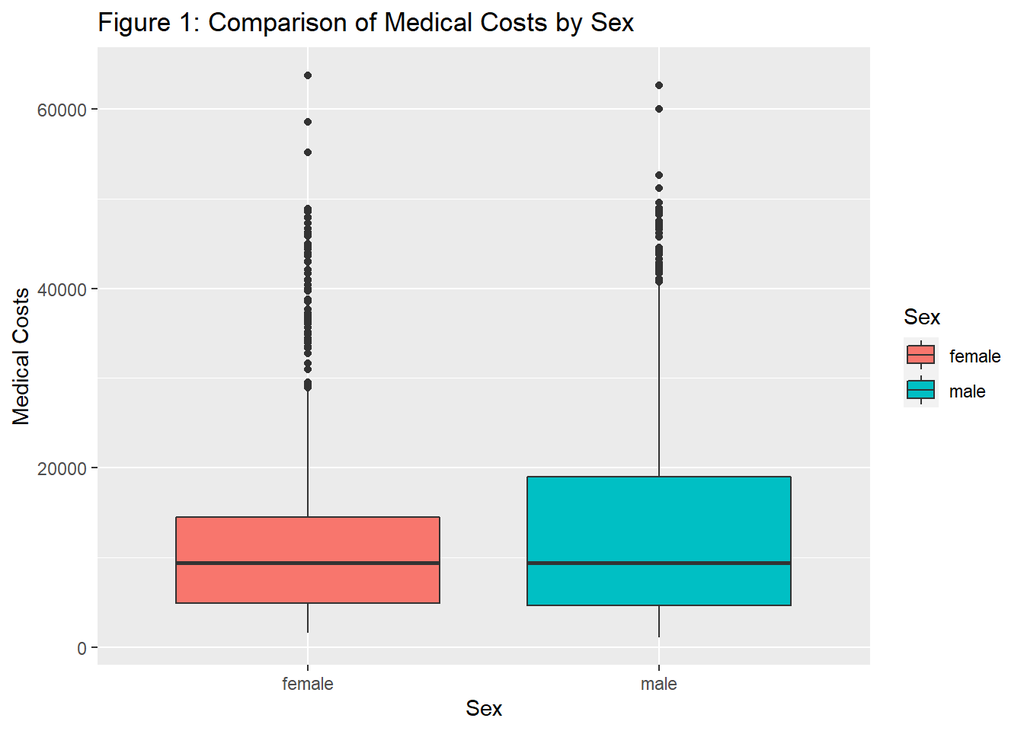

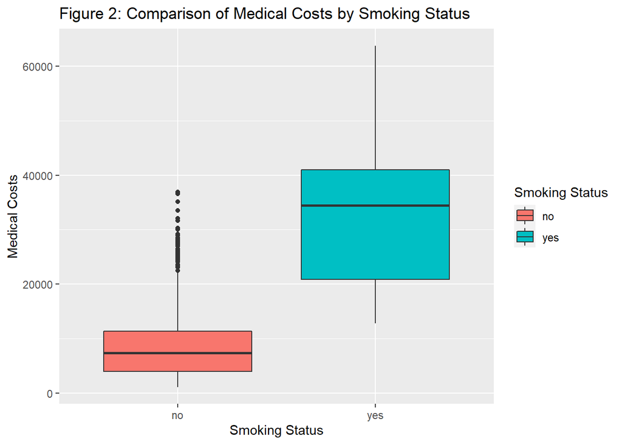

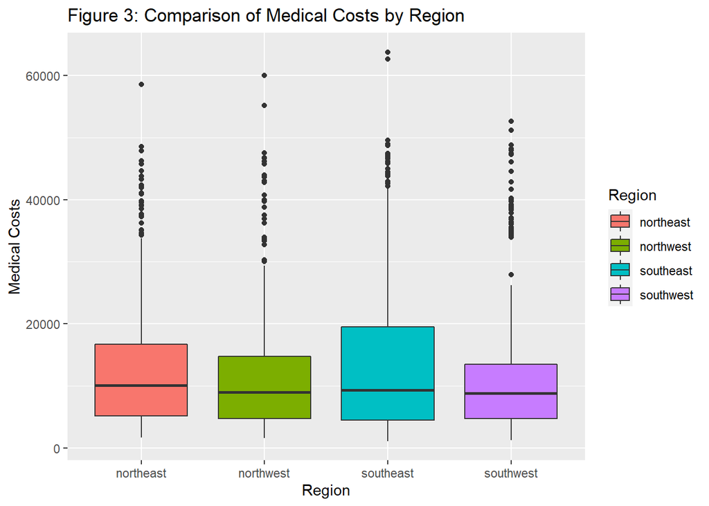

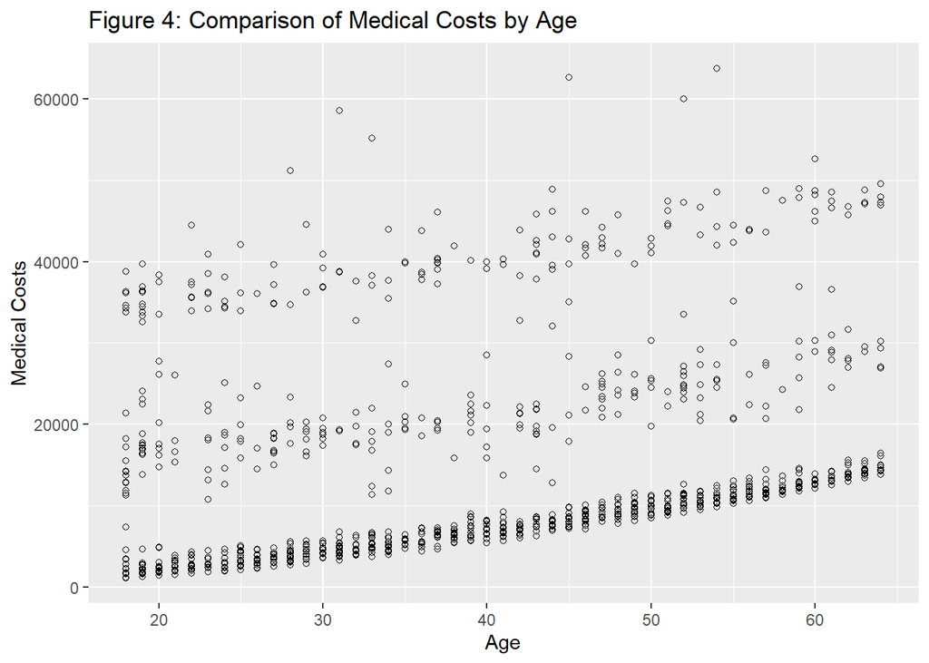

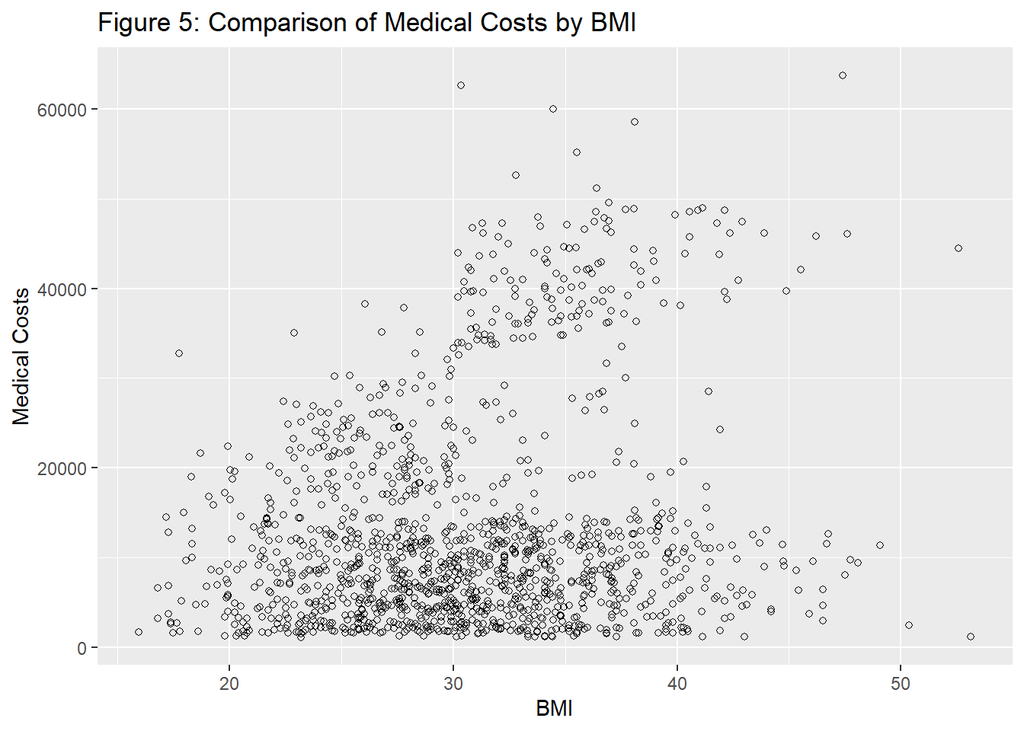

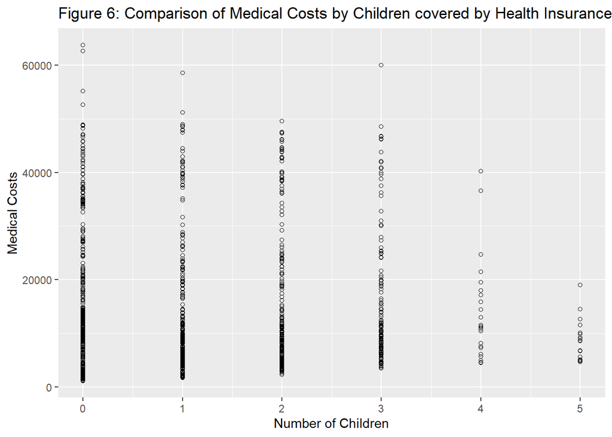

## Multiple Linear Regression Results

- Sex: The slope of -131.3 represents that the average medical costs are $131.3 lower for males than females
- Smoker: The slope of 23848.5 represents that the average medical costs are $23,848.5 higher for smokers than non-smokers
- Region: The slope of -353.0 represents that medical costs for those in the northwest are on average $353 lower than those in the northeast. The slope of -1035.0 represents that medical costs for those in the southeast are on average $1,035 lower than those in the northeast. The slope of -960.0 represents that medical costs for those in the southwest are on average $960 lower than those in the northeast.
- Age: The slope of 256.9 represents that for every additional year of age medical costs go up by an average of $256.9
- BMI: The slope of 339.2 represents that for every additional unit of BMI medical costs go up by an average of $339.2
- Children: The slope of 475.5 represents that for every additional child covered by health insurance medical costs go up by an average of $475.5

## Linear Regression Assumptions

Based on the plots below, homoscedasicity is violated. The variance of the residuals does not stay roughly the same throughout the model. There is wide variance in the residuals thoughout and as a result it fails the hemoscedasicity assumption.

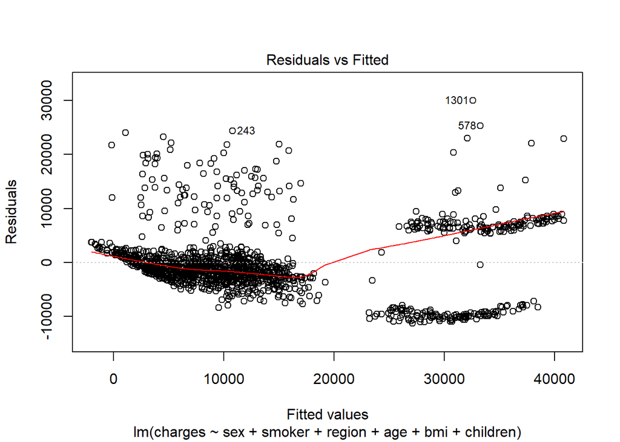

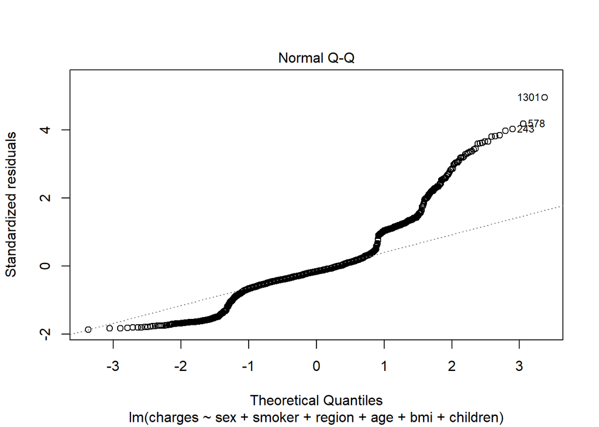

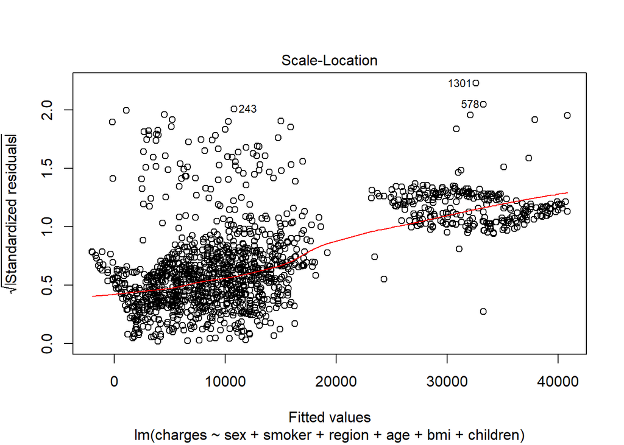

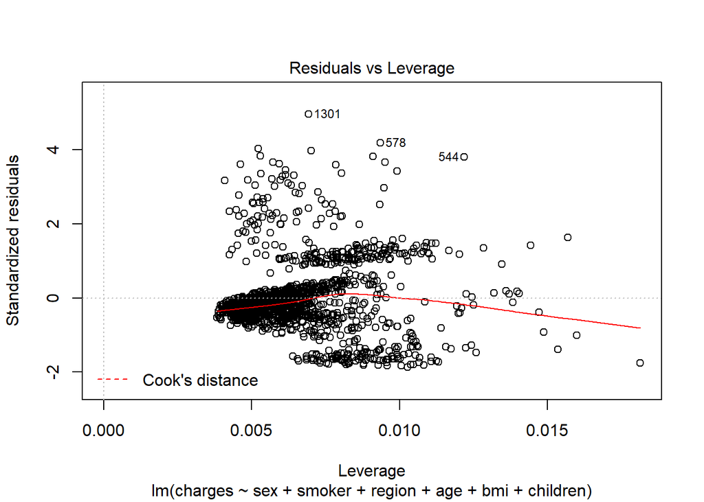